# Temporal bisection is influenced by ensemble statistics of the stimulus set (Data Analysis Report)

Xiuna Zhu

12 Februar 2019

```r
mDist_exp= dat_all%>% dplyr::group_by(Exp) %>%
  summarise(am_Dur = mean(curDur),
            sd_Dur = sd(curDur),
            gm_Dur = gm_mean(curDur))
mDist_exp
```

| Exp | am_Dur | sd_Dur | gm_Dur |
| --- | --- | --- | --- |
| Exp1 | 1000.143 | 416.1604 | 902.7582 |
| Exp2 | 1000.000 | 400.0190 | 909.8326 |
| Exp3 | 925.000 | 368.2943 | 841.5500 |

```r
mDist <-  dat_all %>% dplyr::group_by(NSub, cond, Exp) %>%
  summarise(m_cDur = mean(curDur), n = dplyr::n(),
            sd_Dur = sd(curDur),
            gm_Dur = gm_mean(curDur),
            cDur_se = sd(curDur)/sqrt(n-1))
mDist
```

| NSub | cond | Exp | m_cDur | n | sd_Dur | gm_Dur | cDur_se |
| --- | --- | --- | --- | --- | --- | --- | --- |
| 1 | PS | Exp1 | 888.2857 | 336 | 401.3319 | 800.2084 | 21.92710 |
| 1 | NS | Exp1 | 1112.0000 | 336 | 401.5126 | 1018.4500 | 21.93698 |
| 1 | DF | Exp2 | 800.0000 | 448 | 346.7974 | 727.5822 | 16.40296 |
| 1 | AF | Exp2 | 1200.0000 | 448 | 346.7974 | 1137.7346 | 16.40296 |
| 1 | U-shaped | Exp3 | 925.0000 | 288 | 491.3893 | 781.2750 | 29.00579 |
| 1 | I T-shaped | Exp3 | 925.0000 | 288 | 175.3046 | 906.4752 | 10.34790 |
| 2 | PS | Exp1 | 888.2857 | 336 | 401.3319 | 800.2084 | 21.92710 |
| 2 | NS | Exp1 | 1112.0000 | 336 | 401.5126 | 1018.4500 | 21.93698 |
| 2 | DF | Exp2 | 800.0000 | 448 | 346.7974 | 727.5822 | 16.40296 |
| 2 | AF | Exp2 | 1200.0000 | 448 | 346.7974 | 1137.7346 | 16.40296 |

[output cut: 80 more lines]

# Experiment 1 (Spacing Effect)

Two spacing condition will be tested in Experiment Spacing.

positive skew condition (400, 504, 636, 800, 1008, 1270, and 1600 ms)

negative skew condition (400, 730, 992, 1200, 1366, 1496, and 1600 ms)

twice of the intervals used in paper (Stimulus spacing effects in duration perception are larger for auditory stimuli: data and a model).

The arithmetic mean of set PS = 0.8883, geometric mean = 800, sd = 401; and arithmetic mean of set NS = 1.1120, geometric mean = 1018, sd = 402.

## Range Frequency Theory

To understand the pattern of results concerning schifts in the temporal bisection point, We have to check the distribution of stimuli within the sets firstly.

```r
sumfreq_exp1_sub1 <-  dat_exp1 %>% filter(NSub == 1) %>% group_by(cond, curDur) %>% summarise(count = n())
```

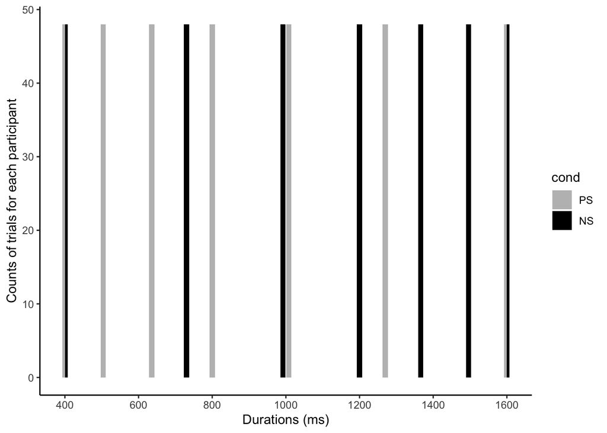

```r
count_exp1 <- sum(sumfreq_exp1_sub1$count)/2
sumfreq_exp1_sub1$freq <- sumfreq_exp1_sub1$count/count_exp1*100
fig_exp1_sub1_dist <- ggplot(data=sumfreq_exp1_sub1, aes(x=curDur, y=count, fill=cond)) +
  geom_bar(stat="identity", position=position_dodge()) +
  xlab('Durations (ms)') + ylab('Counts of trials for each participant') +
  scale_x_continuous(breaks=seq(0, 1600, 200)) +
  scale_color_manual(values = c('gray','black')) +
  scale_fill_manual(values = c('gray','black')) +
  mytheme

fig_exp1_sub1_dist
```

## plot the distribution of stimulus set

```r
mDist_exp1 <-  dat_exp1 %>% filter(NSub == 1) %>% dplyr::group_by(cond) %>%
  dplyr::summarise(m_cDur = mean(curDur), n = dplyr::n(),
                   sd_Dur = sd(curDur),
                   gm_Dur = gm_mean(curDur))
mDist_exp1
```

| cond | m_cDur | n | sd_Dur | gm_Dur |
| --- | --- | --- | --- | --- |
| PS | 888.2857 | 336 | 401.3319 | 800.2084 |
| NS | 1112.0000 | 336 | 401.5126 | 1018.4500 |

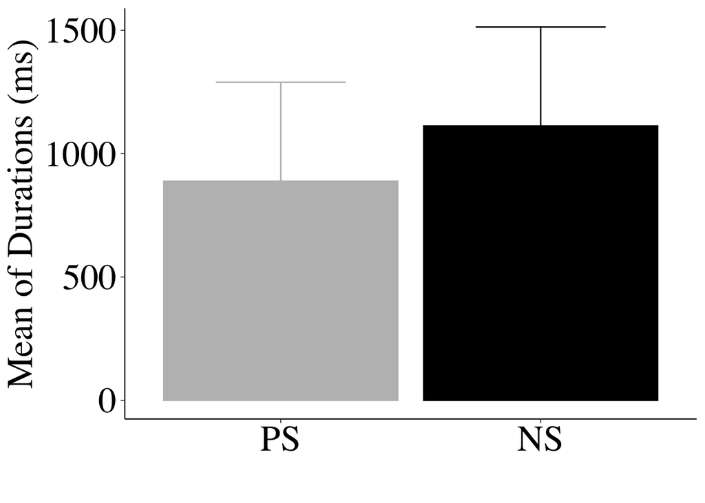

```r
plot_mDist_exp1 <- ggplot(mDist_exp1,aes(cond, m_cDur, color = cond, fill = cond))+
  geom_bar(stat='identity') +
  geom_errorbar(aes(ymin = m_cDur - sd_Dur, ymax = m_cDur + sd_Dur), width =0.5) +
  labs(x = " ", y = "Mean of Durations (ms)") +
  #coord_cartesian(ylim = c(0,1400))+
  scale_color_manual(values = c('gray','black')) +
  scale_fill_manual(values = c('gray','black')) +
  theme(legend.position = "none", legend.title = element_blank())+
  theme(panel.grid.major=element_line(colour=NA))+
  theme(axis.text.y = element_text(size=26,colour = "black"),
        axis.text.x   = element_text(size=26, colour = "black"),
        axis.title.y  = element_text(size=26, colour = "black"),
        axis.title.x  = element_text(size=26, colour = "black"),
        panel.background = element_blank(),
        panel.grid.major = element_blank(),
        panel.grid.minor = element_blank(),
        axis.line = element_line(colour = "black"))

plot_mDist_exp1
```

## fit psychometric functions

By default, quickpsy uses cummulative normal function, this can be shown by fits_exp$funname. With cummulative normal function, the second parameter p2 is the sigma, which defines JND as between 50%-84%. We use logistic function for calculating JND as 75%, so we need to specify this function in quickpsy.

```r
fits_exp1 = quickpsy(dat_exp1, x = curDur, k =RP, prob = .5,
                     grouping = .(cond, NSub), fun = logistic_fun,
                     thresholds = FALSE)
head(fits_exp1$thresholds)
```

|  | cond | NSub | thre | prob | threinf | thresup |
| --- | --- | --- | --- | --- | --- | --- |
| 1 | NS | 1 | 1178.6014 | 0.5 | 1133.6001 | 1218.9231 |
| 2 | NS | 10 | 900.2008 | 0.5 | 856.9682 | 948.2686 |
| 3 | NS | 11 | 614.8768 | 0.5 | 561.0429 | 661.0330 |
| 4 | NS | 12 | 883.5534 | 0.5 | 837.1853 | 921.3621 |
| 5 | NS | 13 | 1024.2448 | 0.5 | 978.4550 | 1066.6072 |
| 6 | NS | 14 | 839.7424 | 0.5 | 799.1231 | 883.3228 |

```r
par_exp1 <-fits_exp1$par %>%  dplyr::select(cond, NSub, parn, par) %>%
  pivot_wider(names_from = parn, values_from = par) %>%
  mutate(jnd = log(3)/p2)
par_exp1$pse <- par_exp1$p1
par_exp1$p1 <-  NULL
par_exp1$p2 <-  NULL
head(par_exp1)
```

| cond | NSub | jnd | pse |
| --- | --- | --- | --- |
| PS | 1 | 128.3157 | 1079.6440 |
| PS | 2 | 105.3192 | 1032.5604 |
| PS | 3 | 183.7201 | 816.7745 |
| PS | 4 | 100.5473 | 663.9814 |
| PS | 5 | 141.6987 | 656.0801 |
| PS | 6 | 184.1902 | 991.0418 |

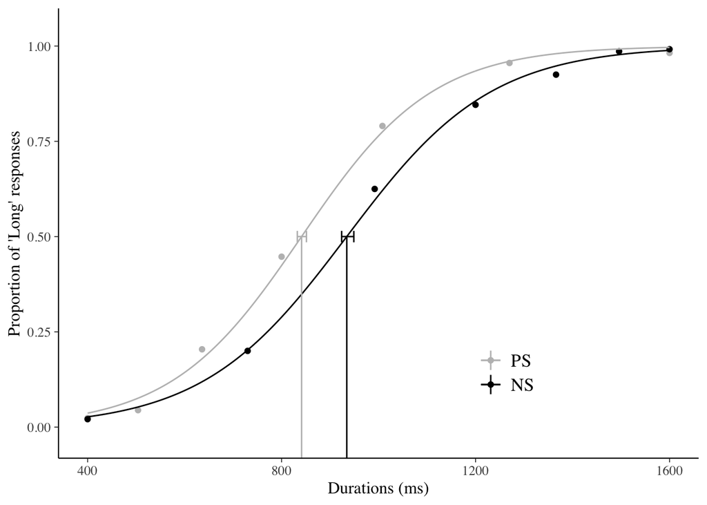

```r
fits_exp1_all = quickpsy(dat_exp1, x = curDur, k =RP, prob = .5, fun = logistic_fun, grouping = .(cond))
# plot fitted function
plot_fit_exp1 <- plot(fits_exp1_all) +
  labs(x = "Durations (ms)", y = "Proportion of 'Long' responses") +
  scale_color_manual(values = c('gray','black')) +
  scale_fill_manual(values = c('gray','black')) +
  theme(legend.position = c(0.7, 0.2), legend.title = element_blank())
plot_fit_exp1
```

$$\beta = 3 / e^{JND}$$

```r
exp1_all_thres<- fits_exp1_all$thresholds
exp1_all_thres$slope = 3/exp(exp1_all_thres$thre/1000) #slope
exp1_all_thres
```

| cond | thre | prob | threinf | thresup | slope |
| --- | --- | --- | --- | --- | --- |
| NS | 934.4398 | 0.5 | 923.8707 | 949.0023 | 1.178418 |
| PS | 841.2594 | 0.5 | 832.4636 | 851.3193 | 1.293501 |

```r
exp1_thres<- fits_exp1$thresholds
exp1_thres$slope = 3/exp(exp1_thres$thre/1000) #slope
exp1_thres
```

| cond | NSub | thre | prob | threinf | thresup | slope |
| --- | --- | --- | --- | --- | --- | --- |
| NS | 1 | 1178.6014 | 0.5 | 1133.6001 | 1218.9231 | 0.9231264 |
| NS | 10 | 900.2008 | 0.5 | 856.9682 | 948.2686 | 1.2194641 |
| NS | 11 | 614.8768 | 0.5 | 561.0429 | 661.0330 | 1.6221225 |
| NS | 12 | 883.5534 | 0.5 | 837.1853 | 921.3621 | 1.2399350 |
| NS | 13 | 1024.2448 | 0.5 | 978.4550 | 1066.6072 | 1.0772026 |
| NS | 14 | 839.7424 | 0.5 | 799.1231 | 883.3228 | 1.2954652 |
| NS | 15 | 1123.7066 | 0.5 | 1075.7057 | 1161.2908 | 0.9752179 |
| NS | 2 | 1142.9646 | 0.5 | 1087.2251 | 1195.2079 | 0.9566168 |
| NS | 3 | 887.1224 | 0.5 | 834.1471 | 945.0167 | 1.2355175 |
| NS | 4 | 830.9426 | 0.5 | 782.4145 | 884.4404 | 1.3069153 |

[output cut: 20 more lines]

## list all of the parameter for each subjects

```r
par_exp1$slope = 3/exp(par_exp1$jnd/1000) #slope

mpars_exp1 = par_exp1%>%
  group_by(cond) %>%
  summarise(m_pse = mean(pse),
            m_jnd = mean(jnd),
            m_slope = mean(slope),
            n = n(),
            pse_se = sd(pse)/sqrt(n-1),
            jnd_se = sd(jnd)/sqrt(n-1),
            slope_se = sd(slope)/sqrt(n-1))
mpars_exp1
```

| cond | m_pse | m_jnd | m_slope | n | pse_se | jnd_se | slope_se |
| --- | --- | --- | --- | --- | --- | --- | --- |
| PS | 842.5154 | 116.8065 | 2.670898 | 15 | 38.35030 | 9.679895 | 0.02564614 |
| NS | 934.2446 | 134.1446 | 2.624896 | 15 | 40.27452 | 9.392417 | 0.02447480 |

List all of the parameters for exp1 and export data for JASP

```r
exp1_jasp <- par_exp1%>%
  unite(pse.jnd.slope, pse, jnd, slope)%>%
  spread(cond, pse.jnd.slope)%>%
  separate(`PS`, c("PSC_pse", "PSC_jnd","PSC_slope"), sep = "_")%>%
  separate(`NS`, c("NSC_pse", "NSC_jnd","NSC_slope"), sep = "_")

exp1_jasp
```

| NSub | PSC_pse | PSC_jnd | PSC_slope | NSC_pse | NSC_jnd | NSC_slope |
| --- | --- | --- | --- | --- | --- | --- |
| 1 | 1079.64395049965 | 128.315726820572 | 2.63872688905038 | 1178.60138183644 | 129.137419581478 | 2.63655955683019 |
| 2 | 1032.56035883889 | 105.319155420821 | 2.70011167494935 | 1142.96464689405 | 184.881413465913 | 2.49360854241797 |
| 3 | 816.774483139682 | 183.720101883055 | 2.49650608104833 | 887.122359785991 | 199.66448931714 | 2.45701647623515 |
| 4 | 663.981394982773 | 100.547278529976 | 2.71302706627462 | 830.942646699481 | 145.70416397593 | 2.59324016994762 |
| 5 | 656.080053580603 | 141.698694524843 | 2.60364814472492 | 770.275107571999 | 184.76523622926 | 2.49389825979668 |
| 6 | 991.041809023331 | 184.190164183784 | 2.49533284342508 | 959.81400201203 | 154.721573075503 | 2.56996097917791 |
| 7 | 908.160462085291 | 135.671499382836 | 2.61938822679816 | 971.49856793988 | 148.957607922692 | 2.58481691813296 |
| 8 | 862.864270845684 | 135.061608235803 | 2.62098625575064 | 1026.78546268341 | 123.127297558048 | 2.65245331536061 |
| 9 | 922.209137600301 | 113.85965339315 | 2.67714957014052 | 859.339704532065 | 105.434524136661 | 2.69980018450126 |
| 10 | 760.62707547603 | 96.3361932995556 | 2.72447594366358 | 900.200788889217 | 111.913152111754 | 2.68236572018372 |

[output cut: 5 more lines]

```r
write.csv(exp1_jasp, file = "jasp/exp1_jasp.csv")
```

## plot PSE

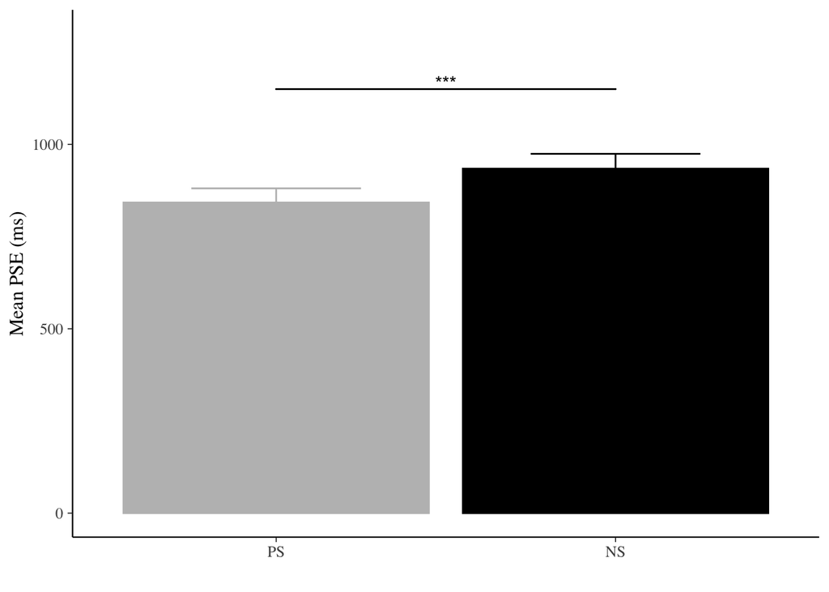

```r
plot_pse_exp1 <- ggplot(mpars_exp1,aes(cond, m_pse, color = cond, fill = cond))+
  geom_bar(stat='identity') +
  geom_errorbar(aes(ymin = m_pse - pse_se, ymax = m_pse + pse_se), width =0.5) +
  geom_signif(comparisons=list(c("PS", "NS")), annotations="***", y_position = 1150, tip_length = 0, vjust=0.4, color = 'black') +
  labs(x = " ", y = "Mean PSE (ms)") +
  coord_cartesian(ylim = c(0,1300)) +
  scale_color_manual(values = c('gray','black')) +
  scale_fill_manual(values = c('gray','black')) +
  theme(legend.position = "none")

plot_pse_exp1
```

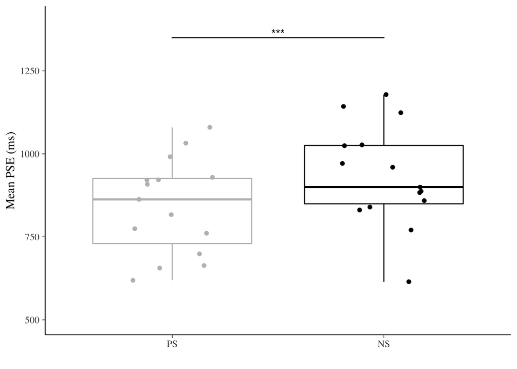

```r
plot_pse_exp1_box <- ggplot(par_exp1,aes(x=cond, y=pse, color = cond))+
  geom_boxplot() +
  geom_jitter(position=position_jitter(0.2))+
  geom_signif(comparisons=list(c("PS", "NS")), annotations="***", y_position = 1350, tip_length = 0, vjust=0.4, color = 'black') +
  labs(x = " ", y = "Mean PSE (ms)") +
  coord_cartesian(ylim = c(500,1400)) +
  scale_color_manual(values = c('gray','black')) +
  scale_fill_manual(values = c('gray','black')) +
  theme(legend.position = "none")

plot_pse_exp1_box
```

## plot JND

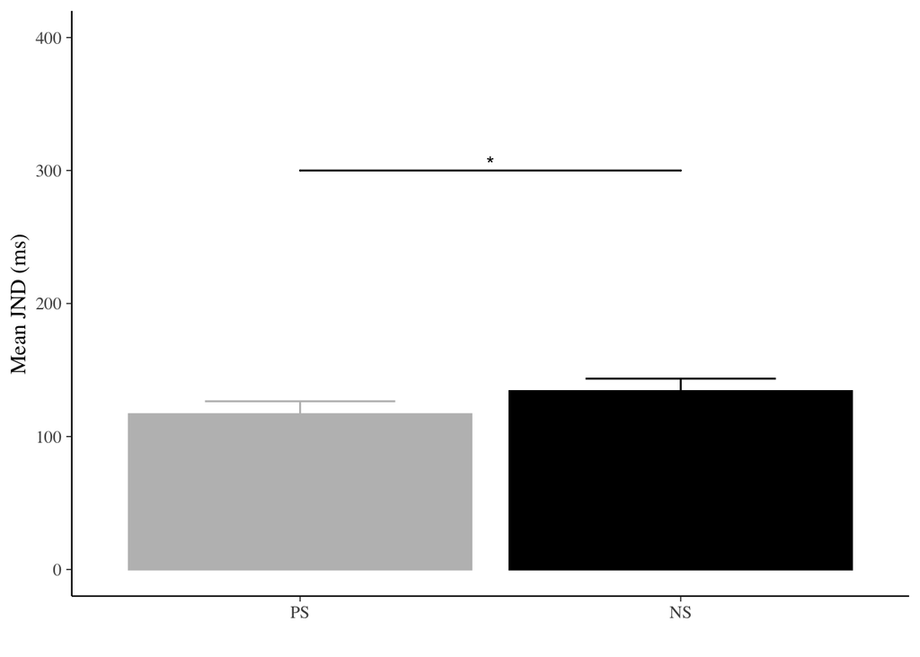

```r
plot_jnd_exp1 <- ggplot(mpars_exp1,aes(cond, m_jnd, color = cond, fill = cond))+
  geom_bar(stat='identity') +
  geom_errorbar(aes(ymin = m_jnd - jnd_se, ymax = m_jnd + jnd_se), width =0.5) +
  labs(x = " ", y = "Mean JND (ms)") +
  geom_signif(comparisons=list(c("PS", "NS")), annotations= "*", y_position = 300, tip_length = 0, vjust=0.4, color = 'black') +
  coord_cartesian(ylim = c(0,400))+
  scale_color_manual(values = c('gray','black')) +
  scale_fill_manual(values = c('gray','black')) + theme(legend.position = "none")

plot_jnd_exp1
```

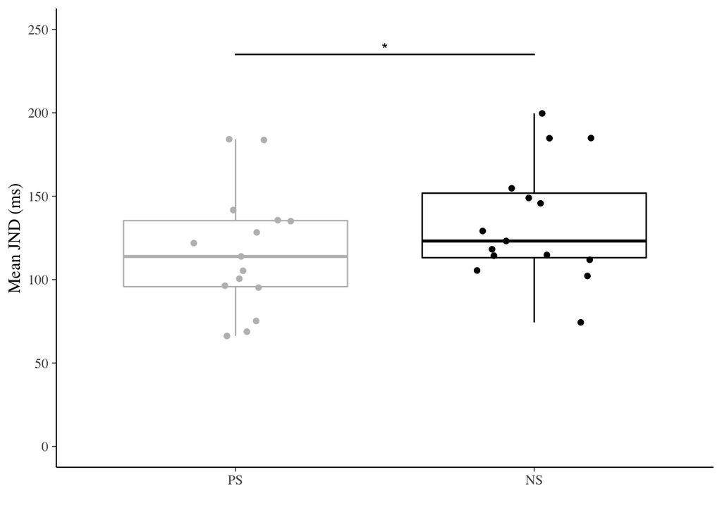

```r
plot_jnd_exp1_box <- ggplot(par_exp1,aes(x=cond, y=jnd, color = cond))+
  geom_boxplot() +
  geom_jitter(position=position_jitter(0.2))+
  labs(x = " ", y = "Mean JND (ms)") +
  geom_signif(comparisons=list(c("PS", "NS")), annotations= "*", y_position = 235, tip_length = 0, vjust=0.4, color = 'black') +
  coord_cartesian(ylim = c(0,250))+
  scale_color_manual(values = c('gray','black')) +
  scale_fill_manual(values = c('gray','black')) + theme(legend.position = "none")

plot_jnd_exp1_box
```

## plot Slope

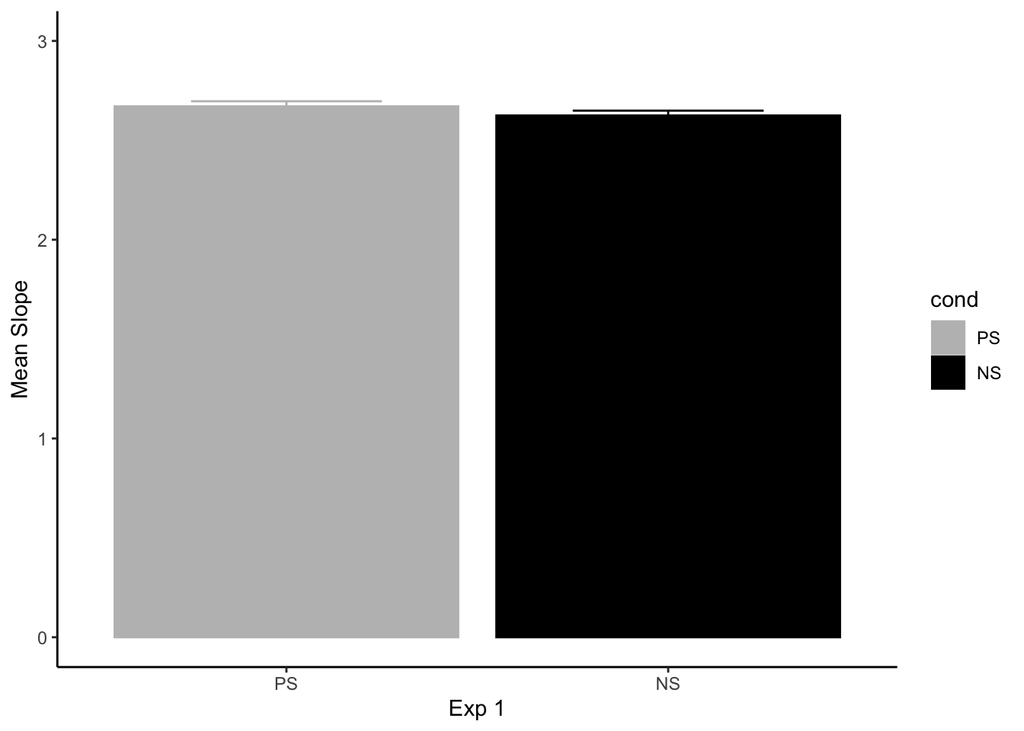

```r
plot_slope_exp1 <- ggplot(mpars_exp1,aes(cond, m_slope, color = cond, fill = cond))+
  geom_bar(stat='identity') +
  geom_errorbar(aes(ymin = m_slope - slope_se, ymax = m_slope + slope_se), width =0.5) +
  labs(x = "Exp 1", y = "Mean Slope") +
  coord_cartesian(ylim = c(0,3))+
  scale_color_manual(values = c('gray','black')) +
  scale_fill_manual(values = c('gray','black'))  +mytheme

plot_slope_exp1
```

## ANOVA and T-test

```r
Anova_exp1_pse<- ezANOVA(data = par_exp1, dv= pse, wid=NSub, within=.(cond))
Anova_exp1_pse
```

```
## $ANOVA
##   Effect DFn DFd      F            p p<.05        ges
## 2   cond   1  14 21.141 0.0004140881     * 0.09428886
```

```r
Anova_exp1_jnd<- ezANOVA(data = par_exp1, dv= jnd, wid=NSub, within=.(cond))
Anova_exp1_jnd
```

```
## $ANOVA
##   Effect DFn DFd        F          p p<.05        ges
## 2   cond   1  14 5.754768 0.03093345     * 0.05947079
```

```r
Anova_exp1_slope<- ezANOVA(data = par_exp1, dv= slope, wid=NSub, within=.(cond))
Anova_exp1_slope
```

```
## $ANOVA
##   Effect DFn DFd       F          p p<.05        ges
## 2   cond   1  14 5.91538 0.02902254     * 0.06053278
```

# Experiment 2

## Range Frequency Theory

A particular focus is the distribution of stimuli within the sets to be judged. To understand the pattern of results concerning schifts in the temporal bisection point, We have to check the frequency of the sets firstly.

```r
sumfreq_exp2_sub1 <-  dat_exp2 %>% filter(NSub == 1) %>% group_by(cond, curDur) %>% summarise(count = n())
```

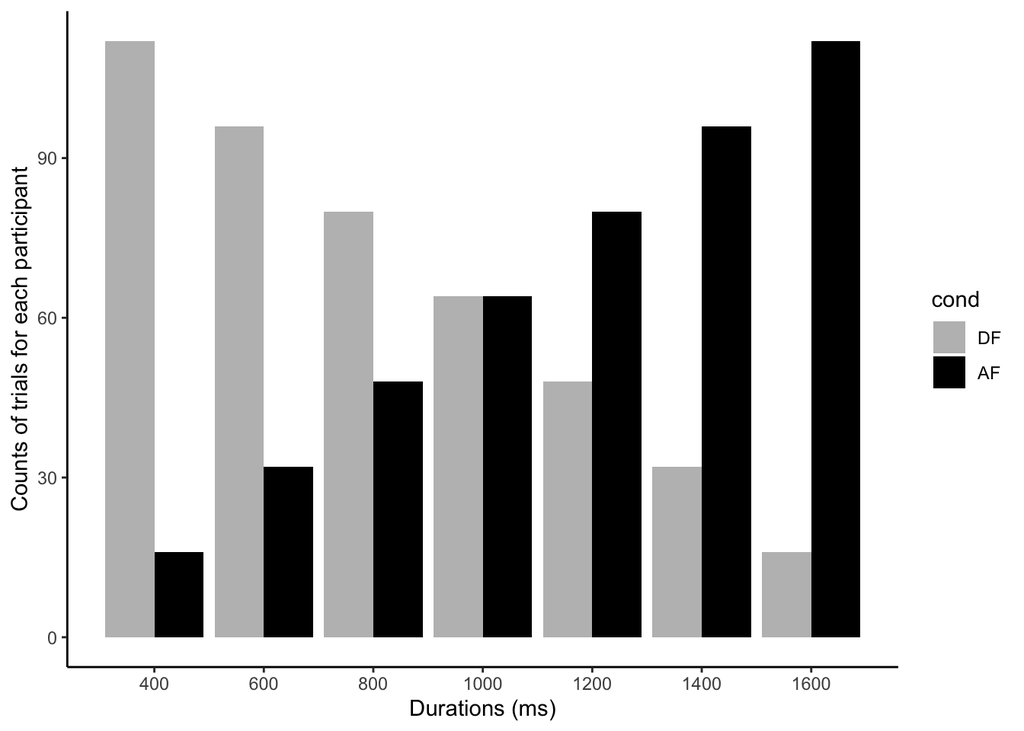

```r
count_exp2 <- sum(sumfreq_exp2_sub1$count)/2
sumfreq_exp2_sub1$freq <- sumfreq_exp2_sub1$count/count_exp2*100
fig_exp2_sub1_dist <- ggplot(data=sumfreq_exp2_sub1, aes(x=curDur, y=count, fill=cond)) +
  geom_bar(stat="identity", position=position_dodge()) +
  xlab('Durations (ms)') + ylab('Counts of trials for each participant') +
  scale_x_continuous(breaks=seq(0, 1600, 200)) +
  scale_color_manual(values = c('gray','black')) +
  scale_fill_manual(values = c('gray','black')) +mytheme

fig_exp2_sub1_dist
```

```r
mDist_exp2 <-  dat_exp2 %>% filter(NSub == 1) %>% dplyr::group_by(cond) %>%
  summarise(m_cDur = mean(curDur), n = dplyr::n(),
            sd_Dur = sd(curDur),
            gm_Dur = gm_mean(curDur))
mDist_exp2
```

| cond | m_cDur | n | sd_Dur | gm_Dur |
| --- | --- | --- | --- | --- |
| DF | 800 | 448 | 346.7974 | 727.5822 |
| AF | 1200 | 448 | 346.7974 | 1137.7346 |

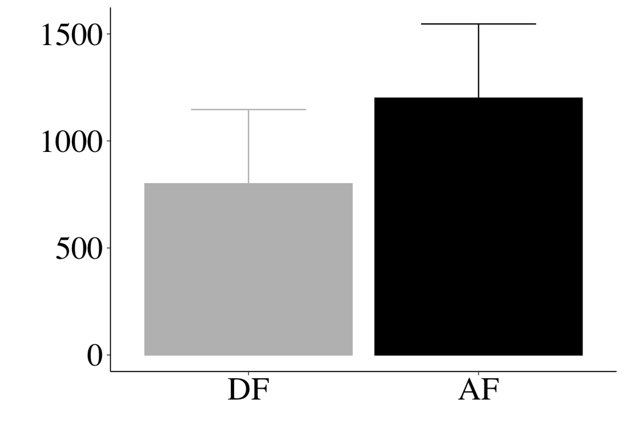

```r
plot_mDist_exp2 <- ggplot(mDist_exp2,aes(cond, m_cDur, color = cond, fill = cond))+
  geom_bar(stat='identity') +
  geom_errorbar(aes(ymin = m_cDur - sd_Dur, ymax = m_cDur + sd_Dur), width =0.5) +
  #geom_text(aes(label=paste("(",m_cDur,",",round(sd_Dur),")") ),size=8, hjust=0.5, vjust=-2, color = 'black')+
  labs(x = " ", y = " ") +
  #coord_cartesian(ylim = c(0,1600))+
  scale_color_manual(values = c('gray','black')) +
  scale_fill_manual(values = c('gray','black')) +
  theme(legend.position = "none", legend.title = element_blank())+
  theme(panel.grid.major=element_line(colour=NA))+
  theme(axis.text.y = element_text(size=26,colour = "black"),
        axis.text.x   = element_text(size=26, colour = "black"),
        axis.title.y  = element_text(size=26, colour = "black"),
        axis.title.x  = element_text(size=26, colour = "black"),
        panel.background = element_blank(),
        panel.grid.major = element_blank(),
        panel.grid.minor = element_blank(),
        axis.line = element_line(colour = "black")
  )

plot_mDist_exp2
```

## Fit psychometric functions

```r
fits_exp2 = quickpsy(dat_exp2, x = curDur, k =RP, prob = .5, grouping = .(cond, NSub), fun = logistic_fun, thresholds = FALSE)
head(fits_exp2$thresholds)
```

|  | cond | NSub | thre | prob | threinf | thresup |
| --- | --- | --- | --- | --- | --- | --- |
| 1 | AF | 1 | 910.7978 | 0.5 | 879.4150 | 939.2311 |
| 2 | AF | 10 | 866.7665 | 0.5 | 686.4474 | 995.4435 |
| 3 | AF | 11 | 1026.7244 | 0.5 | 987.8009 | 1069.4933 |
| 4 | AF | 12 | 1034.9557 | 0.5 | 1007.1460 | 1065.9204 |
| 5 | AF | 13 | 1254.2337 | 0.5 | 1223.6430 | 1289.2736 |
| 6 | AF | 14 | 919.6055 | 0.5 | 875.7458 | 955.3066 |

```r
par_exp2 <- fits_exp2$par %>%  dplyr::select(cond, NSub, parn, par) %>%
  pivot_wider(names_from = parn, values_from = par) %>%
  mutate(jnd = log(3)/p2)
par_exp2$pse <-  par_exp2$p1
par_exp2$p1 <-  NULL
par_exp2$p2 <-  NULL
head(par_exp2)
```

| cond | NSub | jnd | pse |
| --- | --- | --- | --- |
| DF | 1 | 82.22603 | 778.9366 |
| DF | 2 | 105.45391 | 695.1449 |
| DF | 3 | 64.39733 | 815.0988 |
| DF | 4 | 53.66784 | 815.7178 |
| DF | 5 | 95.57373 | 998.9084 |
| DF | 6 | 123.29853 | 1158.0529 |

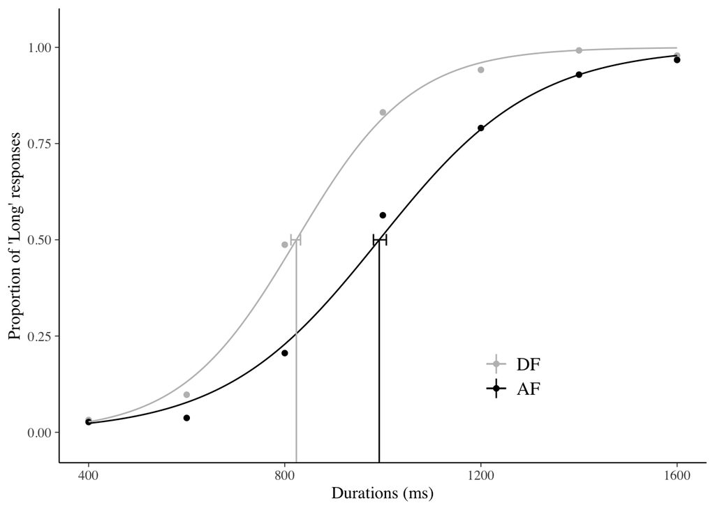

```r
fits_exp2_all = quickpsy(dat_exp2, x = curDur, k =RP, prob = .5,fun = logistic_fun,
                         grouping = .(cond))
# plot fitted function
plot_fit_exp2 <- plot(fits_exp2_all) +
  labs(x = "Durations (ms)", y = "Proportion of 'Long' responses") +
  scale_color_manual(values = c('gray','black')) +
  scale_fill_manual(values = c('gray','black')) +
  theme(legend.position = c(0.7, 0.2), legend.title = element_blank())
plot_fit_exp2
```

## Average fitted paramters and plot

```r
par_exp2$slope = 3/exp(par_exp2$pse/1000) #add slope

par_exp2
```

| cond | NSub | jnd | pse | slope |
| --- | --- | --- | --- | --- |
| DF | 1 | 82.22603 | 778.9366 | 1.3766813 |
| DF | 2 | 105.45391 | 695.1449 | 1.4970064 |
| DF | 3 | 64.39733 | 815.0988 | 1.3277868 |
| DF | 4 | 53.66784 | 815.7178 | 1.3269651 |
| DF | 5 | 95.57373 | 998.9084 | 1.1048437 |
| DF | 6 | 123.29853 | 1158.0529 | 0.9422915 |
| DF | 7 | 76.32550 | 811.1759 | 1.3330058 |
| DF | 8 | 72.72676 | 813.6820 | 1.3296693 |
| DF | 9 | 80.96581 | 785.9842 | 1.3670130 |
| DF | 10 | 405.55640 | 564.9335 | 1.7051939 |

[output cut: 20 more lines]

```r
mpse_exp2 = par_exp2%>%
  group_by(cond) %>%
  summarise(m_pse = mean(pse),
            m_jnd = mean(jnd),
            m_slope = mean(slope),
            n = n(),
            pse_se = sd(pse)/sqrt(n-1),
            jnd_se = sd(jnd)/sqrt(n-1),
            slope_se = sd(slope)/sqrt(n-1))
mpse_exp2
```

| cond | m_pse | m_jnd | m_slope | n | pse_se | jnd_se | slope_se |
| --- | --- | --- | --- | --- | --- | --- | --- |
| DF | 820.5071 | 108.3328 | 1.331925 | 15 | 36.65839 | 22.69864 | 0.04697062 |
| AF | 997.1217 | 138.7784 | 1.120520 | 15 | 44.65226 | 28.03120 | 0.04613294 |

## Export for JASP

List all of the parameters for Exp2 and export data for JASP

```r
exp2_jasp <- par_exp2%>%
  unite(pse.jnd.slope, pse, jnd, slope)%>%
  spread(cond, pse.jnd.slope)%>%
  separate(DF, c("DF_pse", "DF_jnd","DF_slope"), sep = "_")%>%
  separate(AF, c("AF_pse", "AF_jnd", "AF_slope"), sep = "_")

exp2_jasp
```

| NSub | DF_pse | DF_jnd | DF_slope | AF_pse | AF_jnd | AF_slope |
| --- | --- | --- | --- | --- | --- | --- |
| 1 | 778.936553420024 | 82.2260250435934 | 1.37668128273614 | 910.797753355796 | 89.3346806930806 | 1.20660971110313 |
| 2 | 695.14491705274 | 105.453910276465 | 1.49700638648191 | 864.817237245084 | 135.735237482284 | 1.2633855366045 |
| 3 | 815.098815322695 | 64.3973326502023 | 1.32778676992313 | 829.622517909272 | 126.828031315954 | 1.3086417545659 |
| 4 | 815.717824121319 | 53.667836751547 | 1.32696511256266 | 1066.63340896323 | 103.416509981228 | 1.03249569846098 |
| 5 | 998.908394864104 | 95.5737288499958 | 1.10484371856447 | 1025.18602714156 | 109.354577098447 | 1.07618917719893 |
| 6 | 1158.0529216096 | 123.298527697367 | 0.942291473003746 | 1411.19073047417 | 151.787306914371 | 0.731558241946161 |
| 7 | 811.175926663868 | 76.3255043128214 | 1.33300575964907 | 1023.6811743638 | 135.032801397756 | 1.07780990264237 |
| 8 | 813.68204230608 | 72.7267631867149 | 1.32966927561733 | 792.501713007242 | 75.2589871160524 | 1.3581324746412 |
| 9 | 785.984204796024 | 80.9658110934868 | 1.36701302228211 | 854.018845838623 | 81.6281832243522 | 1.2771019926727 |
| 10 | 564.933455037223 | 405.556395975533 | 1.70519390856238 | 866.766546753854 | 505.161431501801 | 1.26092520591682 |

[output cut: 5 more lines]

```r
write.csv(exp2_jasp, file = "jasp/exp2_jasp.csv")
```

## plot PSE

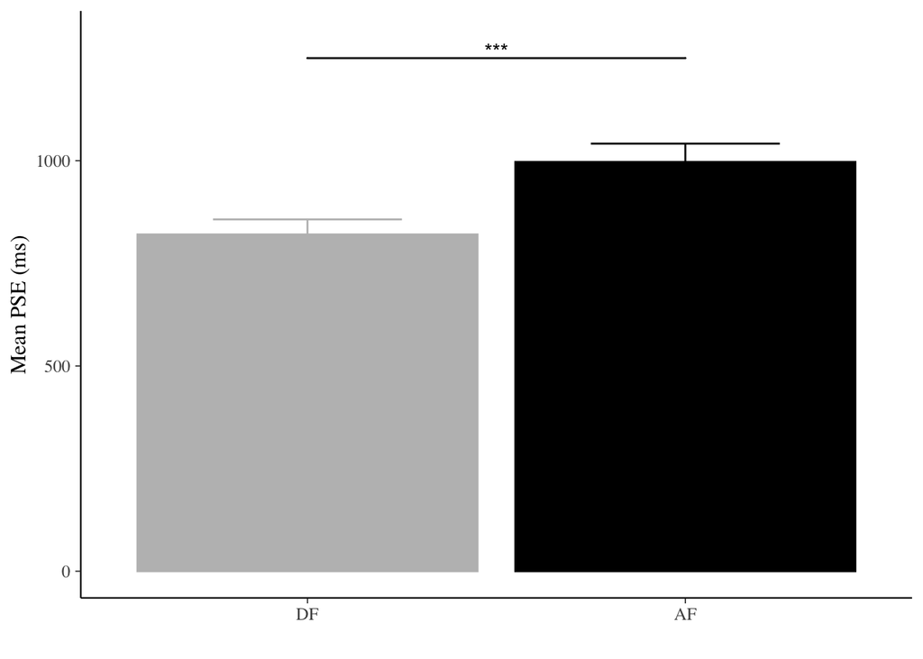

```r
plot_pse_exp2 <- ggplot(mpse_exp2,aes(cond, m_pse, color = cond, fill = cond))+
  geom_bar(stat='identity') +
  geom_errorbar(aes(ymin = m_pse - pse_se, ymax = m_pse + pse_se), width =0.5) +
  geom_signif(comparisons=list(c("DF", "AF")), annotations="***", y_position = 1250, tip_length = 0, vjust=0.4, color = 'black') +
  labs(x = " ", y = "Mean PSE (ms)") +
  coord_cartesian(ylim = c(0,1300))+
  scale_color_manual(values = c('gray','black')) +
  scale_fill_manual(values = c('gray','black')) +
  theme(legend.position = "none")

plot_pse_exp2
```

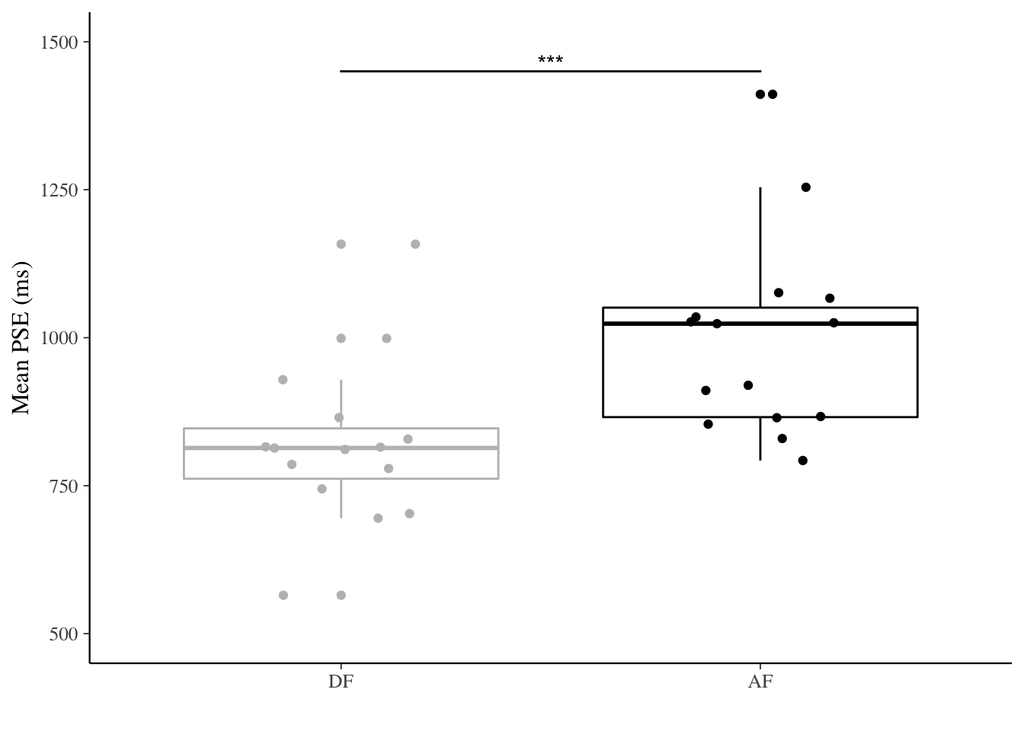

```r
plot_pse_exp2_box <- ggplot(par_exp2,aes(x=cond, y=pse, color = cond))+
  geom_boxplot() +
  geom_jitter(position=position_jitter(0.2))+
  geom_signif(comparisons=list(c("DF", "AF")), annotations="***", y_position = 1450, tip_length = 0, vjust=0.4, color = 'black') +
  labs(x = " ", y = "Mean PSE (ms)") +
  coord_cartesian(ylim = c(500,1500))+
  scale_color_manual(values = c('gray','black')) +
  scale_fill_manual(values = c('gray','black')) +
  theme(legend.position = "none")

plot_pse_exp2_box
```

## plot JND

[figure not shown]

```r
plot_jnd_exp2 <- ggplot(mpse_exp2,aes(cond, m_jnd, color = cond, fill = cond))+
  geom_bar(stat='identity') +
  geom_errorbar(aes(ymin = m_jnd - jnd_se, ymax = m_jnd + jnd_se), width =0.5) +
  geom_signif(comparisons=list(c("DF", "AF")), annotations="***", y_position = 210, tip_length = 0, vjust=0.4, color = 'black') +
  labs(x = " ", y = "Mean JND (ms)") +
  coord_cartesian(ylim = c(0,250))+
  scale_color_manual(values = c('gray','black')) +
  scale_fill_manual(values = c('gray','black')) +
  theme(legend.position = "none")

plot_jnd_exp2
```

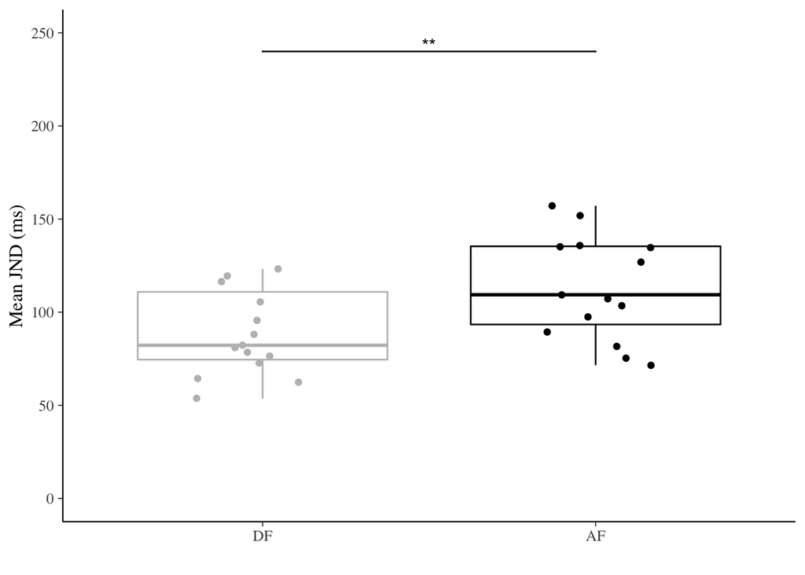

```r
plot_jnd_exp2_box <- ggplot(par_exp2,aes(x=cond, y=jnd, color = cond))+
  geom_boxplot() +
  geom_jitter(position=position_jitter(0.2)) +
  geom_signif(comparisons=list(c("DF", "AF")), annotations="**", y_position = 240, tip_length = 0, vjust=0.4, color = 'black') +
  labs(x = " ", y = "Mean JND (ms)") +
  coord_cartesian(ylim = c(0,250))+
  scale_color_manual(values = c('gray','black')) +
  scale_fill_manual(values = c('gray','black')) +
  theme(legend.position = "none")
plot_jnd_exp2_box
```

## plot Slope

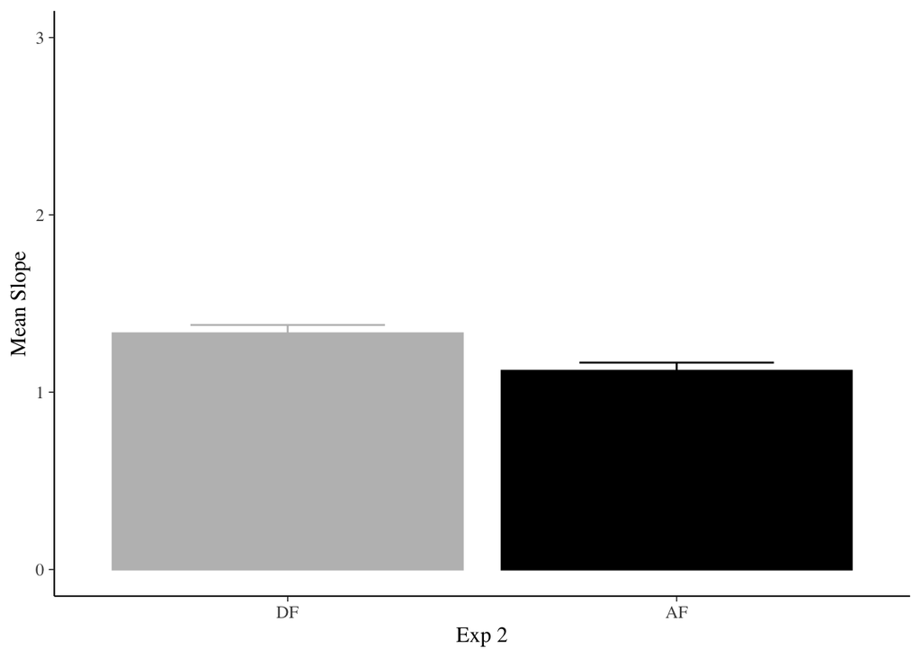

```r
plot_slope_exp2 <- ggplot(mpse_exp2,aes(cond, m_slope, color = cond, fill = cond))+
  geom_bar(stat='identity') +
  geom_errorbar(aes(ymin = m_slope - slope_se, ymax = m_slope + slope_se), width =0.5) +
  coord_cartesian(ylim = c(0,3))+
  labs(x = "Exp 2", y = "Mean Slope") +
  scale_color_manual(values = c('gray','black')) +
  scale_fill_manual(values = c('gray','black')) +
  theme(legend.position = "none", legend.title = element_blank())

plot_slope_exp2
```

## ANOVA

```r
Anova_exp2_pse <- ezANOVA(data = par_exp2, dv= pse, wid=NSub, within=.(cond))
Anova_exp2_pse
```

```
## $ANOVA
##   Effect DFn DFd        F            p p<.05       ges
## 2   cond   1  14 26.82816 0.0001397069     * 0.2634143
```

```r
Anova_exp2_jnd <- ezANOVA(data = par_exp2, dv= jnd, wid=NSub, within=.(cond))
Anova_exp2_jnd
```

```
## $ANOVA
##   Effect DFn DFd        F           p p<.05        ges
## 2   cond   1  14 15.38038 0.001534559     * 0.02654009
```

```r
Anova_exp2_slope <- ezANOVA(data = par_exp2, dv= slope, wid=NSub, within=.(cond))
Anova_exp2_slope
```

```
## $ANOVA
##   Effect DFn DFd       F           p p<.05       ges
## 2   cond   1  14 27.1914 0.000131057     * 0.2829209
```

# Experiment 3

Two distributions (a normal and a U-shaped distribution) will be tested in Experiment 3. It is designed to use 8 intervals (400, 550, 700, 850, 1000, 1150, 1300, and 1450 ms) in Experiment 3.

## Range Frequency Theory

To understand the pattern of results concerning schifts in the temporal bisection point, We have to check the distribution of stimuli within the sets firstly.

```r
sumfreq_exp3_sub1 <-  dat_exp3 %>% filter(NSub ==1) %>% group_by(cond, curDur) %>% summarise(count = n())
```

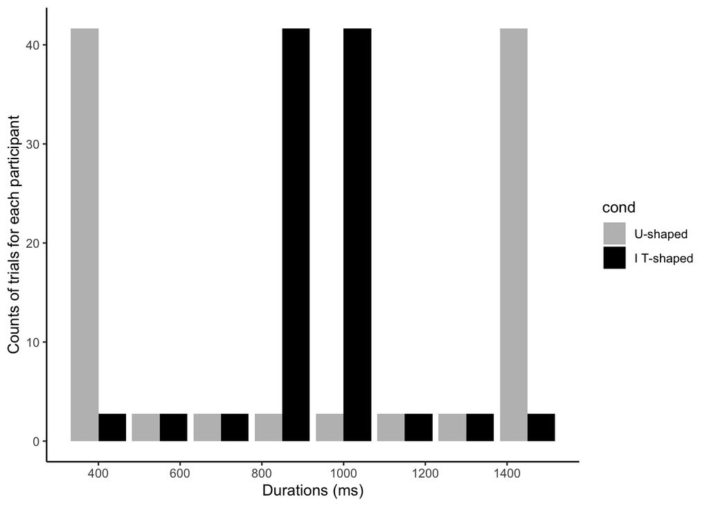

```r
count_exp3 <- sum(sumfreq_exp3_sub1$count)/2
sumfreq_exp3_sub1$freq <- sumfreq_exp3_sub1$count/count_exp3*100

fig_exp3_sub1_dist <- ggplot(data=sumfreq_exp3_sub1, aes(x=curDur, y=freq, fill=cond)) +
  geom_bar(stat="identity", position=position_dodge()) +
  #geom_smooth(method="loess",se = FALSE)+
  xlab('Durations (ms)') + ylab('Counts of trials for each participant') +
  scale_x_continuous(breaks=seq(0, 1600, 200)) +
  scale_color_manual(values = c('gray','black')) +
  scale_fill_manual(values = c('gray','black')) +mytheme

fig_exp3_sub1_dist
```

```r
mDist_exp3 <-  dat_exp3 %>% filter(NSub == 1) %>% dplyr::group_by(cond) %>%
  summarise(m_cDur = mean(curDur), n = dplyr::n(),
            sd_Dur = sd(curDur),
            gm_Dur = gm_mean(curDur))
mDist_exp3
```

| cond | m_cDur | n | sd_Dur | gm_Dur |
| --- | --- | --- | --- | --- |
| U-shaped | 925 | 288 | 491.3893 | 781.2750 |
| I T-shaped | 925 | 288 | 175.3046 | 906.4752 |

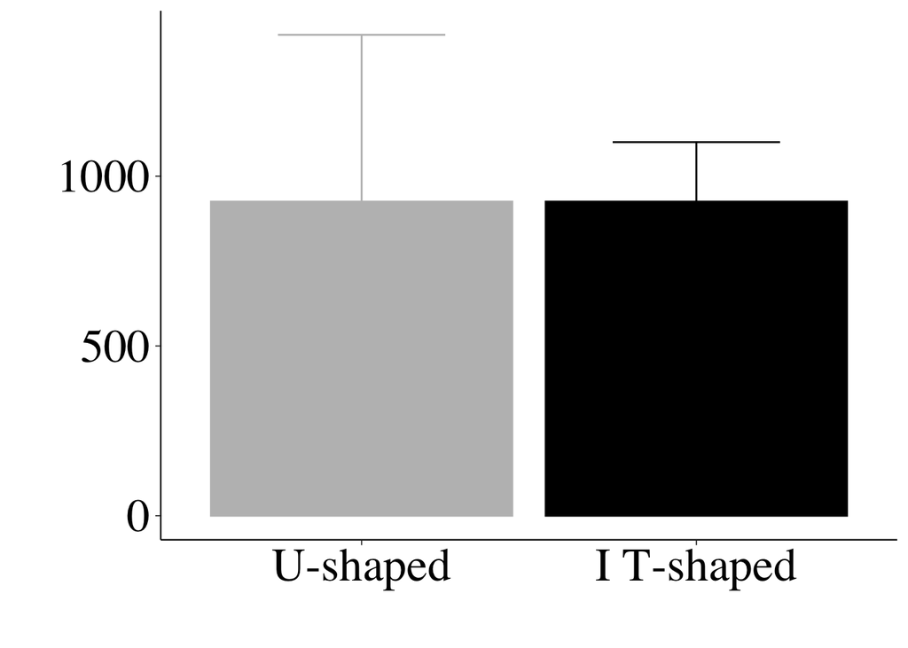

```r
plot_mDist_exp3 <- ggplot(mDist_exp3,aes(cond, m_cDur, color = cond, fill = cond))+
  geom_bar(stat='identity') +
  geom_errorbar(aes(ymin = m_cDur - sd_Dur, ymax = m_cDur + sd_Dur), width =0.5) +
  labs(x = " ", y = " ") +
  #coord_cartesian(ylim = c(0,1200))+
  scale_color_manual(values = c('gray','black')) +
  scale_fill_manual(values = c('gray','black')) +
  theme(legend.position = "none", legend.title = element_blank())+
  theme(panel.grid.major=element_line(colour=NA))+
  theme(axis.text.y = element_text(size=26,colour = "black"),
        axis.text.x   = element_text(size=26, colour = "black"),
        axis.title.y  = element_text(size=26, colour = "black"),
        axis.title.x  = element_text(size=26, colour = "black"),
        panel.background = element_blank(),
        panel.grid.major = element_blank(),
        panel.grid.minor = element_blank(),
        axis.line = element_line(colour = "black"))

plot_mDist_exp3
```

## Fit psychometric functions

```r
fits_exp3 = quickpsy(dat_exp3, x = curDur, k =RP, prob = .5,
                     grouping = .(cond, NSub),
                     fun = logistic_fun,
                     thresholds = FALSE)
head(fits_exp3$thresholds)
```

|  | cond | NSub | thre | prob | threinf | thresup |
| --- | --- | --- | --- | --- | --- | --- |
| 1 | I T-shaped | 1 | 927.7740 | 0.5 | 908.9281 | 942.5727 |
| 2 | I T-shaped | 10 | 895.2923 | 0.5 | 876.2805 | 916.7357 |
| 3 | I T-shaped | 11 | 813.2165 | 0.5 | 764.4348 | 851.9118 |
| 4 | I T-shaped | 12 | 685.4741 | 0.5 | 604.3869 | 749.2486 |
| 5 | I T-shaped | 13 | 696.9397 | 0.5 | 659.3911 | 744.6536 |
| 6 | I T-shaped | 14 | 761.1096 | 0.5 | 711.9444 | 803.2479 |

```r
par_exp3 <- fits_exp3$par %>%  dplyr::select(cond, NSub, parn, par) %>%
  pivot_wider(names_from = parn, values_from = par) %>%
  mutate(jnd = log(3)/p2)
par_exp3$pse <-  par_exp3$p1
par_exp3$p1 <- NULL
par_exp3$p2 <-NULL
head(par_exp3)
```

| cond | NSub | jnd | pse |
| --- | --- | --- | --- |
| U-shaped | 1 | 64.47039 | 943.7949 |
| U-shaped | 2 | 127.54262 | 772.9727 |
| U-shaped | 3 | 70.61915 | 1176.8161 |
| U-shaped | 4 | 116.99762 | 910.2916 |
| U-shaped | 5 | 139.93477 | 887.7345 |
| U-shaped | 6 | 50.75993 | 737.5934 |

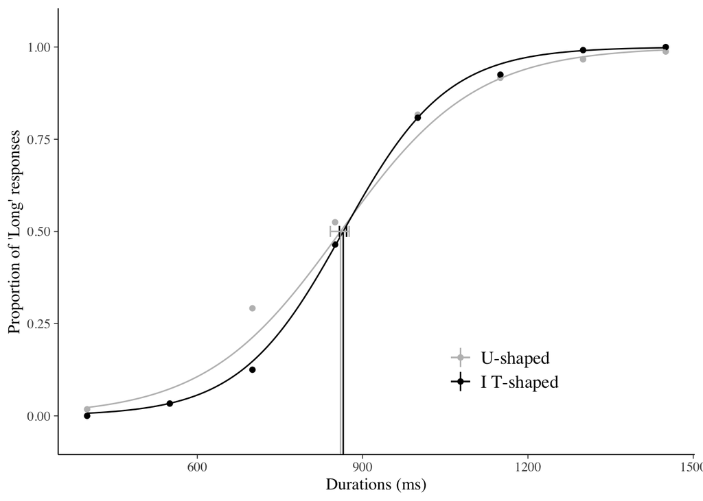

```r
fits_exp3_all = quickpsy(dat_exp3, x = curDur, k =RP, prob = .5, fun = logistic_fun,
                         grouping = .(cond), thresholds = FALSE)
# plot fitted function
plot_fit_exp3 <- plot(fits_exp3_all) +
  labs(x = "Durations (ms)", y = "Proportion of 'Long' responses") +
  scale_color_manual(values = c('gray','black')) +
  scale_fill_manual(values = c('gray','black')) +
  theme(legend.position = c(0.7, 0.2), legend.title = element_blank())
plot_fit_exp3
```

## List all of the parameter for each subjects

```r
par_exp3$slope = 3/exp(par_exp3$pse/1000) #add slope

mpars_exp3 = par_exp3%>%
  group_by(cond) %>%
  summarise(m_pse = mean(pse), m_jnd = mean(jnd), m_slope = mean(slope), n = n(),pse_se = sd(pse)/sqrt(n-1), jnd_se = sd(jnd)/sqrt(n-1),slope_se = sd(slope)/sqrt(n-1))
mpars_exp3
```

| cond | m_pse | m_jnd | m_slope | n | pse_se | jnd_se | slope_se |
| --- | --- | --- | --- | --- | --- | --- | --- |
| U-shaped | 862.9942 | 111.75450 | 1.273531 | 15 | 31.45359 | 11.002247 | 0.03751259 |
| I T-shaped | 864.0733 | 86.37098 | 1.270162 | 15 | 26.47711 | 8.035457 | 0.03396866 |

##Export for JASP

List all of the parameters for Exp3 and export data for JASP

```r
exp3_jasp <- par_exp3%>%
  unite(pse.jnd.slope, pse, jnd, slope)%>%
  spread(cond, pse.jnd.slope)%>%
  separate(`U-shaped`, c("U_pse", "U_jnd", "U_slope"), sep = "_")%>%
  separate(`I T-shaped`, c("B_pse", "B_jnd", "B_slope"), sep = "_")

exp3_jasp
```

| NSub | U_pse | U_jnd | U_slope | B_pse | B_jnd | B_slope |
| --- | --- | --- | --- | --- | --- | --- |
| 1 | 943.794934135244 | 64.4703944941718 | 1.16744471314634 | 927.774028536005 | 56.5127495930524 | 1.18629886168304 |
| 2 | 772.972732373332 | 127.542618599802 | 1.38491609460949 | 871.719088573784 | 85.4703957730635 | 1.25469585938492 |
| 3 | 1176.81611546272 | 70.6191527712196 | 0.924775913222035 | 846.73301982316 | 61.4975310477793 | 1.28644071443552 |
| 4 | 910.291583255554 | 116.997618364009 | 1.20722061545926 | 931.268048349741 | 83.0722643064283 | 1.18216114280069 |
| 5 | 887.73449133897 | 139.934766701707 | 1.23476145469373 | 981.536087454187 | 160.646016283221 | 1.12420509221943 |
| 6 | 737.593440956551 | 50.7599321320032 | 1.43479050314126 | 866.994878586989 | 62.110312532918 | 1.26063732942004 |
| 7 | 938.179131045843 | 132.541051170598 | 1.17401929627659 | 1054.27438263674 | 95.6807814055383 | 1.04533552039385 |
| 8 | 770.173858292229 | 81.6626985804087 | 1.3887977299415 | 920.664485799132 | 68.5422638435447 | 1.19476295640861 |
| 9 | 765.87300262068 | 97.375089621584 | 1.39478361151439 | 830.691152379117 | 75.6518437161412 | 1.30724404183331 |
| 10 | 980.817858534252 | 123.11027237855 | 1.12501281886019 | 895.29226885342 | 81.8621392109435 | 1.22546457844994 |

[output cut: 5 more lines]

```r
write.csv(exp3_jasp, file = "jasp/exp3_jasp.csv")
```

## plot PSE

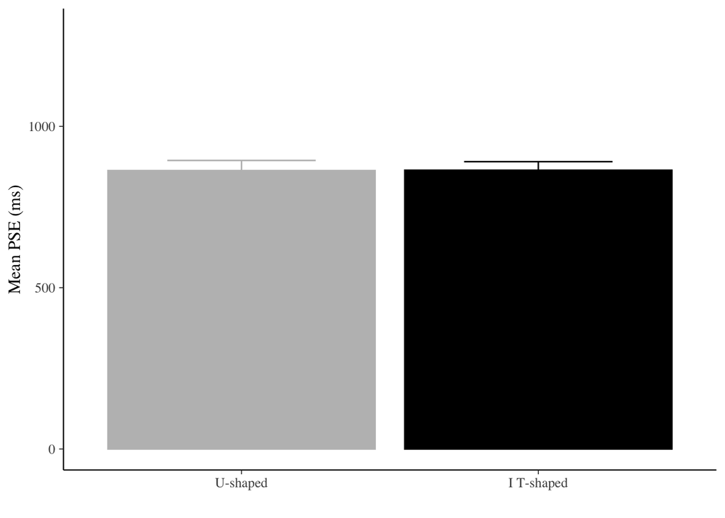

```r
plot_pse_exp3 <- ggplot(mpars_exp3,aes(cond, m_pse, color = cond, fill = cond))+
  geom_bar(stat='identity') +
  geom_errorbar(aes(ymin = m_pse - pse_se, ymax = m_pse + pse_se), width =0.5) +
  coord_cartesian(ylim = c(0,1300)) +
  #geom_signif(comparisons=list(c("U-shaped", "I T-shaped")), annotations="ns", y_position = 1100, tip_length = 0, vjust=0.4, color = 'black') +
  labs(x = " ", y = "Mean PSE (ms)") +
  scale_color_manual(values = c('gray','black')) +
  scale_fill_manual(values = c('gray','black')) +
  theme(legend.position = "none", legend.title = element_blank())


plot_pse_exp3
```

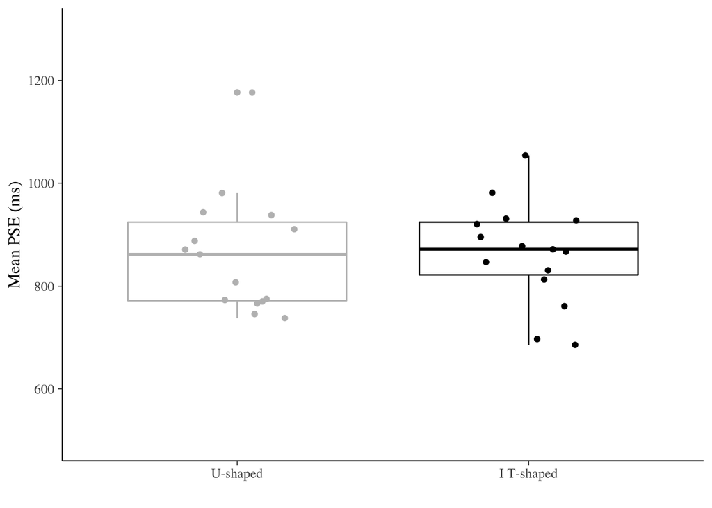

```r
plot_pse_exp3_box <- ggplot(par_exp3,aes(x=cond, y=pse, color = cond))+
  geom_boxplot() +
  geom_jitter(position=position_jitter(0.2))+
  coord_cartesian(ylim = c(500,1300)) +
  labs(x = " ", y = "Mean PSE (ms)") +
  scale_color_manual(values = c('gray','black')) +
  scale_fill_manual(values = c('gray','black')) +
  theme(legend.position = "none", legend.title = element_blank())

plot_pse_exp3_box
```

## plot JND

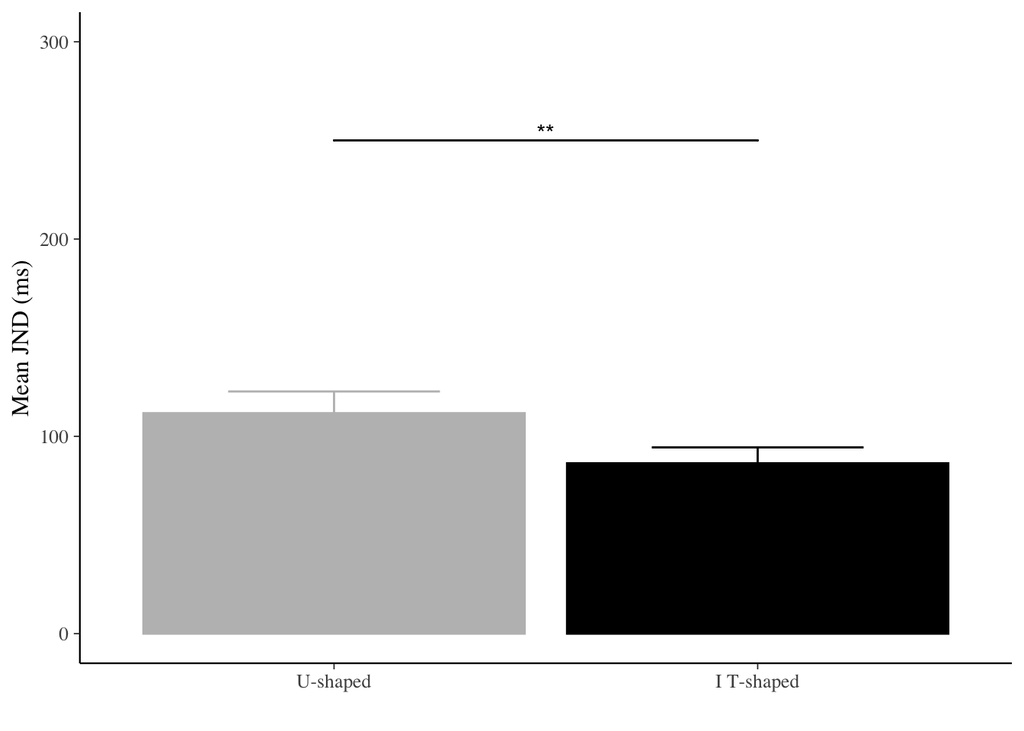

```r
plot_jnd_exp3 <- ggplot(mpars_exp3,aes(cond, m_jnd, color = cond, fill = cond))+
  geom_bar(stat='identity') +
  geom_errorbar(aes(ymin = m_jnd - jnd_se, ymax = m_jnd + jnd_se), width =0.5) +
  coord_cartesian(ylim = c(0,300))+
  geom_signif(comparisons=list(c("U-shaped", "I T-shaped")), annotations="**", y_position = 250, tip_length = 0, vjust=0.4, color = 'black') +
  labs(x = " ", y = "Mean JND (ms)") +
  scale_color_manual(values = c('gray','black')) +
  scale_fill_manual(values = c('gray','black')) +
  theme(legend.position = "none")

plot_jnd_exp3
```

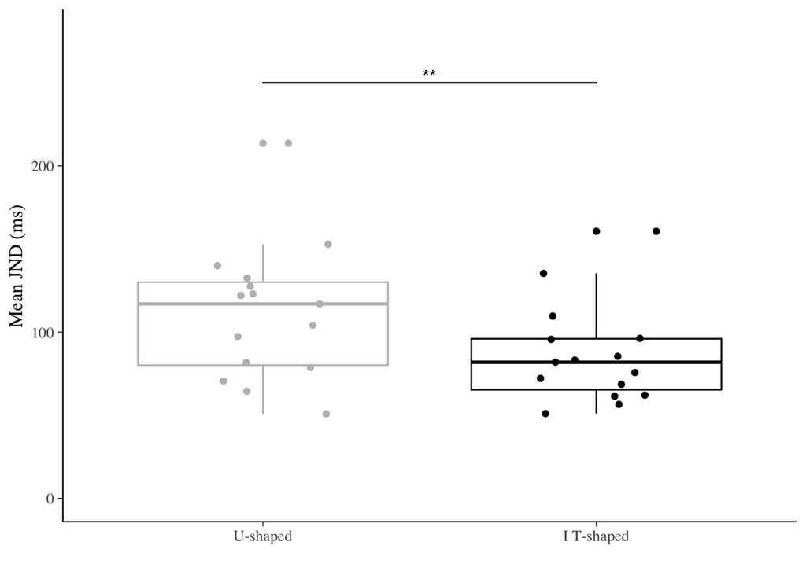

```r
plot_jnd_exp3_box <- ggplot(par_exp3,aes(x=cond, y=jnd, color = cond))+
  geom_boxplot() +
  geom_jitter(position=position_jitter(0.2))+
  coord_cartesian(ylim = c(0,280))+
  geom_signif(comparisons=list(c("U-shaped", "I T-shaped")), annotations="**", y_position = 250, tip_length = 0, vjust=0.4, color = 'black') +
  labs(x = " ", y = "Mean JND (ms)") +
  scale_color_manual(values = c('gray','black')) +
  scale_fill_manual(values = c('gray','black')) +
  theme(legend.position = "none")

plot_jnd_exp3_box
```

## plot Slope

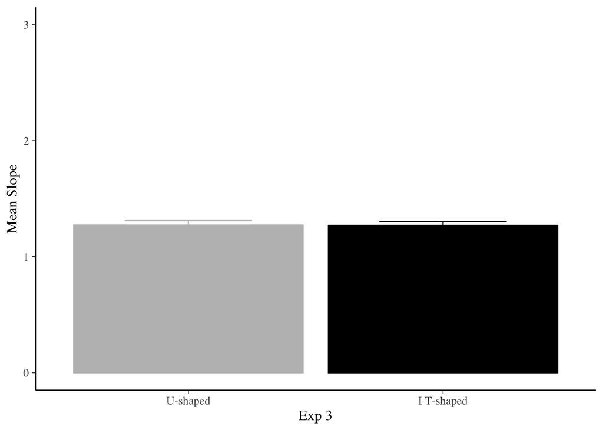

```r
plot_slope_exp3 <- ggplot(mpars_exp3,aes(cond, m_slope, color = cond, fill = cond))+
  geom_bar(stat='identity') +
  geom_errorbar(aes(ymin = m_slope - slope_se, ymax = m_slope + slope_se), width =0.5) +
  coord_cartesian(ylim = c(0,3))+
  labs(x = "Exp 3", y = "Mean Slope") +
  scale_color_manual(values = c('gray','black')) +
  scale_fill_manual(values = c('gray','black')) +
  theme(legend.position = "none", legend.title = element_blank())

plot_slope_exp3
```

## ANOVA

```r
Anova_exp3_pse<- ezANOVA(data = par_exp3, dv= pse, wid=NSub, within=.(cond))
Anova_exp3_pse
```

```
## $ANOVA
##   Effect DFn DFd           F         p p<.05          ges
## 2   cond   1  14 0.001077279 0.9742799       2.635956e-05
```

```r
Anova_exp3_jnd<- ezANOVA(data = par_exp3, dv= jnd, wid=NSub, within=.(cond))
Anova_exp3_jnd
```

```
## $ANOVA
##   Effect DFn DFd       F           p p<.05       ges
## 2   cond   1  14 9.17102 0.009029073     * 0.1172533
```

```r
Anova_exp3_slope<- ezANOVA(data = par_exp3, dv= slope, wid=NSub, within=.(cond))
Anova_exp3_slope
```

```
## $ANOVA
##   Effect DFn DFd           F         p p<.05          ges
## 2   cond   1  14 0.007242754 0.9333835       0.0001696177
```

#### Export the observed paratmeters for model comprision

```r
#merge parameters of experiment 1,2 and 3
par_exp <- rbind(par_exp1, par_exp2)
par_exp <- rbind(par_exp, par_exp3)
write.csv(par_exp, 'modelling/psy_quickpsy_observed.csv')
head(par_exp)
```

| cond | NSub | jnd | pse | slope |
| --- | --- | --- | --- | --- |
| PS | 1 | 128.3157 | 1079.6440 | 2.638727 |
| PS | 2 | 105.3192 | 1032.5604 | 2.700112 |
| PS | 3 | 183.7201 | 816.7745 | 2.496506 |
| PS | 4 | 100.5473 | 663.9814 | 2.713027 |
| PS | 5 | 141.6987 | 656.0801 | 2.603648 |
| PS | 6 | 184.1902 | 991.0418 | 2.495333 |

```r
prob_exp <- rbind(fits_exp1$averages,  fits_exp2$averages)
prob_exp <- rbind(prob_exp,   fits_exp3$averages)
write.csv(prob_exp, 'modelling/prob_exp.csv')
head(prob_exp)
```

| cond | NSub | curDur | n | RP | prob |
| --- | --- | --- | --- | --- | --- |
| PS | 1 | 400 | 48 | 0 | 0.00000000 |
| PS | 1 | 504 | 48 | 0 | 0.00000000 |
| PS | 1 | 636 | 48 | 1 | 0.02083333 |
| PS | 1 | 800 | 48 | 2 | 0.04166667 |
| PS | 1 | 1008 | 48 | 19 | 0.39583333 |
| PS | 1 | 1270 | 48 | 43 | 0.89583333 |

## plot figure 1 in manuscript

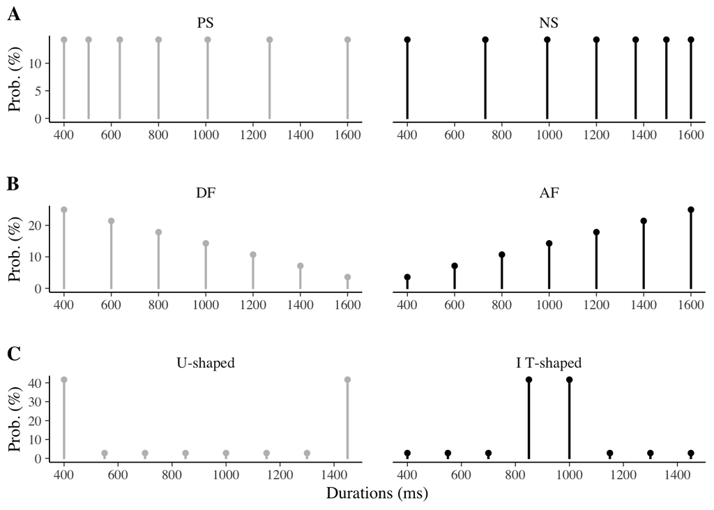

```r
fig_exp1_sub1_dist2 <- ggplot(data=sumfreq_exp1_sub1, aes(x=curDur, y=freq, fill=cond, color = cond)) +
  geom_bar(stat="identity", position=position_dodge(),width = 3) +
  geom_point()+
  xlab('') + ylab('Prob. (%)') +
  scale_x_continuous(breaks=seq(0, 1600, 200)) +
  scale_y_continuous(breaks=seq(0, 50, 5)) +
  scale_color_manual(values = c('gray','black')) +
  scale_fill_manual(values = c('gray','black')) +
  theme(legend.position = "none", legend.title = element_blank()) + facet_wrap(~cond)

fig_exp2_sub1_dist_2 <- ggplot(data=sumfreq_exp2_sub1, aes(x=curDur, y=freq, fill=cond, color = cond)) +
  geom_bar(stat="identity", position=position_dodge(), width = 3) +
  geom_point()+
  scale_x_continuous(breaks=seq(0, 1600, 200)) +
  scale_y_continuous(breaks=seq(0, 50, 10)) +
  xlab('') + ylab('Prob. (%)') +
  scale_color_manual(values = c('gray','black')) +
  scale_fill_manual(values = c('gray','black')) +
  theme(legend.position = 'none', legend.title = element_blank()) + facet_wrap(~cond)

fig_exp3_sub1_dist2 <- ggplot(data=sumfreq_exp3_sub1, aes(x=curDur, y=freq, fill=cond, color = cond)) +
  geom_bar(stat="identity", position=position_dodge(), width = 3) +
  geom_point()+
  xlab('Durations (ms)') + ylab('Prob. (%)') +
  scale_x_continuous(breaks=seq(0, 1600, 200)) +
  scale_y_continuous(breaks=seq(0, 50, 10)) +
  scale_color_manual(values = c('gray','black')) +
  scale_fill_manual(values = c('gray','black')) +
  theme(legend.position = "none", legend.title = element_blank())+ facet_wrap(~cond)

plot_grid(fig_exp1_sub1_dist2, fig_exp2_sub1_dist_2, fig_exp3_sub1_dist2,  ncol = 1, labels = c("A", "B", "C"), rel_heights = c(3,3,3))
```

## plot Figure 2 in manuscript

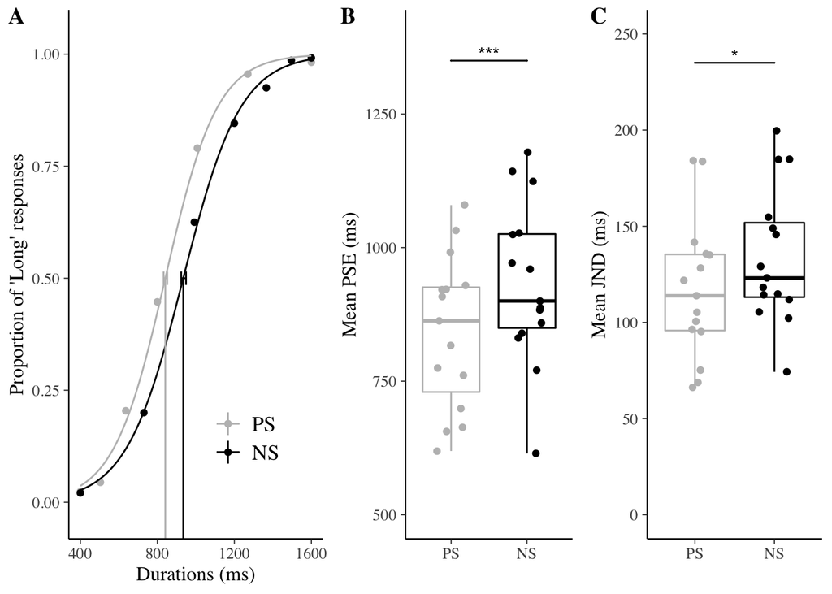

```r
plot_grid(plot_fit_exp1, plot_pse_exp1_box, plot_jnd_exp1_box,  nrow = 1, labels = c("A", "B", "C"), rel_widths = c(4,3,3))
```

## plot Figure 3 in manuscript

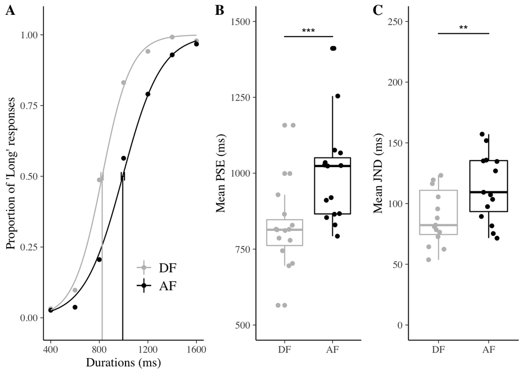

```r
plot_grid(plot_fit_exp2, plot_pse_exp2_box, plot_jnd_exp2_box,  nrow = 1, labels = c("A", "B", "C"), rel_widths = c(4,3,3))
```

## plot Figure 4 in manuscript

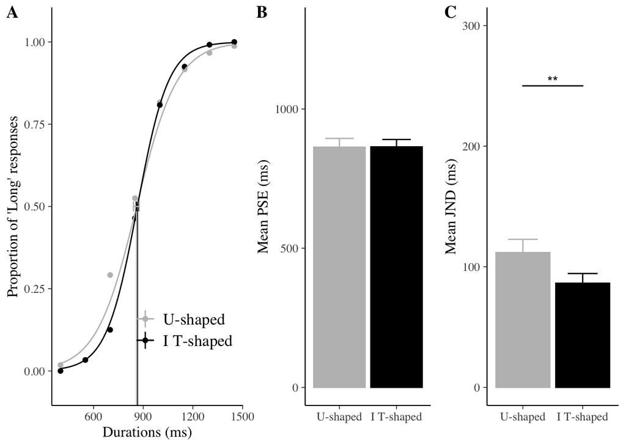

```r
plot_grid(plot_fit_exp3, plot_pse_exp3, plot_jnd_exp3,  nrow = 1, labels = c("A", "B", "C"), rel_widths = c(4,3,3))
```